# Final Documentation

Tianying Zhang(based on someone’s notebook on Kaggle)

5/6/2018

# Introduction

A video game is an electronic game that involves interaction with a user interface to generate visual feedback on a video device such as a TV screen or computer monitor. The word video in video game traditionally referred to a raster display device, but as of the 2000s, it implies any type of display device that can produce two- or three-dimensional images. Some theorists categorize video games as an art form, but this designation is controversial.

The electronic systems used to play video games are known as platforms; examples of these are personal computers and video game consoles. These platforms range from large mainframe computers to small handheld computing devices. Specialized video games such as arcade games, in which the video game components are housed in a large, typically coin-operated chassis, while common in the 1980s in video arcades, have gradually declined due to the widespread availability of affordable home video game consoles (e.g., PlayStation 4, Xbox One and Nintendo Switch) and video games on desktop and laptop computers and smartphones.

The input device used for games, the game controller, varies across platforms. Common controllers include gamepads, joysticks, mouse devices, keyboards, the touchscreens of mobile devices, or even a person’s body with the help of Kinect sensor. Players typically view the game on a video screen or television or computer monitor, or sometimes on virtual reality head-mounted display goggles. There are often game sound effects, music and voice actor lines which come from loudspeakers or headphones. Some games in the 2000s include haptic, vibration-creating effects, force feedback peripherals and virtual reality headsets.(source: wikipedia)

I will review the video game market through

– datasets provides by Metacritic

– live topic-related text data from Twitter.

# Different attamps

At first, my proposal is to analyze the different laptop brands. However, when it comes to bestbuy API and other data source, there are no free source. So after seaching for the free source. I change the topic to video games.

[figure not shown]

# Video Game Market Review

The Video Game data is provided by Metacritic.com which includes over 16000 games from 1980 to 2016 and their related information such as game name, platform, year of release, genre, publisher, and global sales. The following table represent as a sample of the dataset, and also the top 10 global sales game from the Metacritic dataset. (source from: introduction of Metacritic dataset)

| Name | Platform | Genre | Publisher | Global_Sales |
| --- | --- | --- | --- | --- |
| Wii Sports | Wii | Sports | Nintendo | 82.53 |
| Super Mario Bros. | NES | Platform | Nintendo | 40.24 |
| Mario Kart Wii | Wii | Racing | Nintendo | 35.52 |
| Wii Sports Resort | Wii | Sports | Nintendo | 32.77 |
| Pokemon Red/Pokemon Blue | GB | Role-Playing | Nintendo | 31.37 |
| Tetris | GB | Puzzle | Nintendo | 30.26 |
| New Super Mario Bros. | DS | Platform | Nintendo | 29.80 |
| Wii Play | Wii | Misc | Nintendo | 28.92 |
| New Super Mario Bros. Wii | Wii | Platform | Nintendo | 28.32 |
| Duck Hunt | NES | Shooter | Nintendo | 28.31 |

As we could observe from the above time, the top 10 best sell game are varying in platform, genre, but they are all from the same publisher – Nintendo.

It is one of the world’s largest video game companies by market capitalization, creating some of the best-known and top-selling video game franchises, such as Mario and Pokémon.(By the way, I collected all of the versions of Pokémon)

[figure not shown]

Does Nintendo also stay the topest by compare market share with other Game Publisher?

## Video Game Publisher

Through 1980 to 2016, the top 10 publishers for overall sales video game are list in the following table.

| Publisher | Total.Sales | Avg.Sales |
| --- | --- | --- |
| Nintendo | 1788.81 | 2.5337252 |
| Electronic Arts | 1116.96 | 0.8237168 |
| Activision | 731.16 | 0.7422944 |
| Sony Computer Entertainment | 606.48 | 0.8827948 |
| Ubisoft | 471.61 | 0.5054770 |
| Take-Two Interactive | 403.82 | 0.9569194 |
| THQ | 338.44 | 0.4733427 |
| Konami Digital Entertainment | 282.39 | 0.3385971 |
| Sega | 270.35 | 0.4237461 |
| Namco Bandai Games | 254.62 | 0.2711608 |

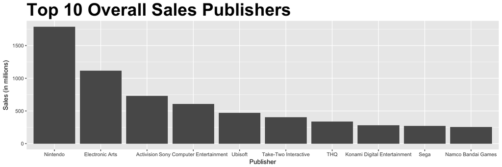

I obeserve that Nintendo has a significant higher overall game sales compare to other video game publishers.

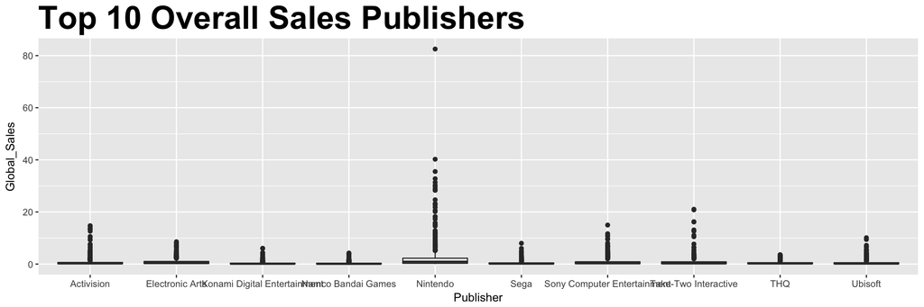

Besides overall revenue, from the boxplot above, Nintendo also shows the highest distribution of global sales for each of their video game. However, the boxplot also indicate that the gloabl sales for most video games is extremely low (less than 1 million dollars)

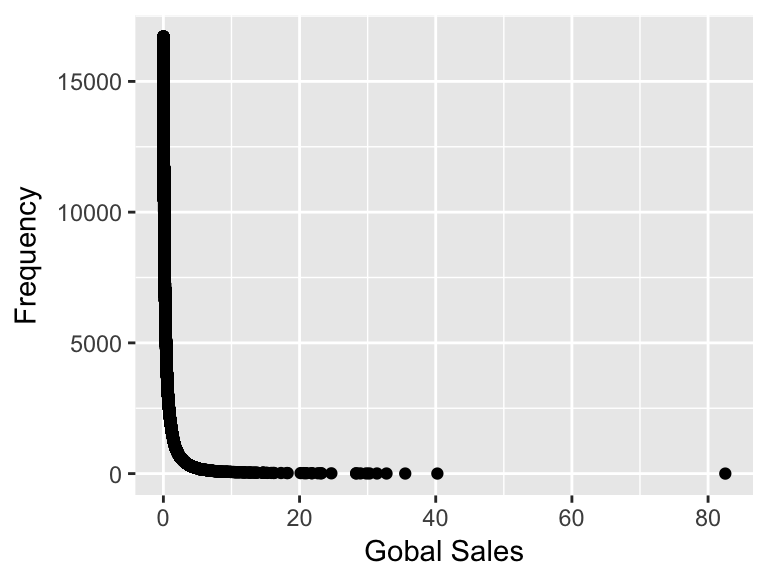

The frequency plot prove the same conclusion from the boxplot. For 16719 games data collected from Metacritic.com, over 15000 games have global sales less than 1 million. It is challenge for company to success in Video Game market.

## Video Game Genre

Video game genres are used to categorize video games based on their gameplay interaction rather than visual or narrative differences.Unlike individual game, each game genre has some game developer.

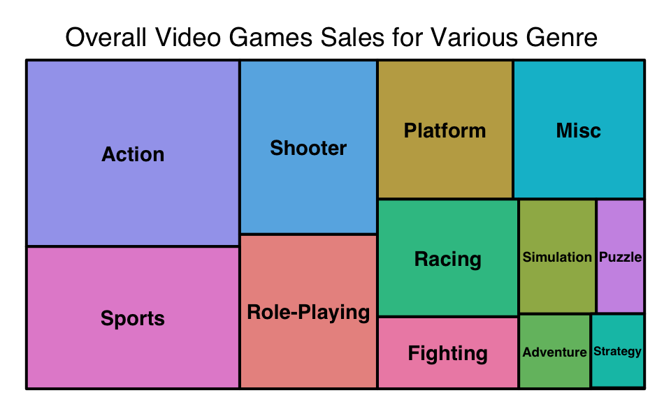

From the treemap above, the hottest game genre is Action, however, other types of genre still have significant proportions in the video game marketing.

## Video Game Platform

The electronic systems used to play video games are known as platforms. With the development of the game design, the graphic, sound, control technologies are changing in a short period in order to provides the best game service to the customers.

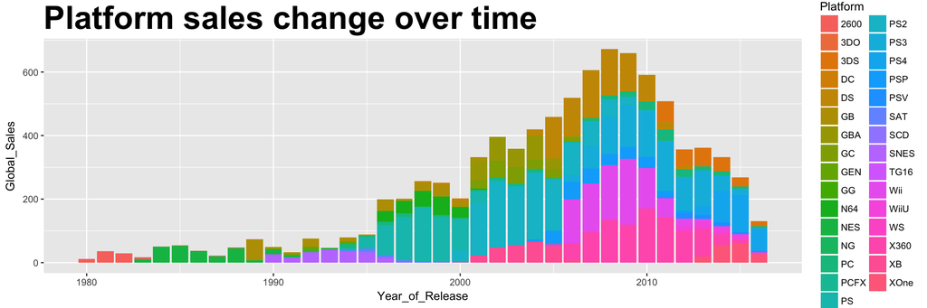

From the barplot above, most of the video game platform only stay in market for couple years. But, for some popular game platform, it could last for more than five years. Let’s have a closer look.

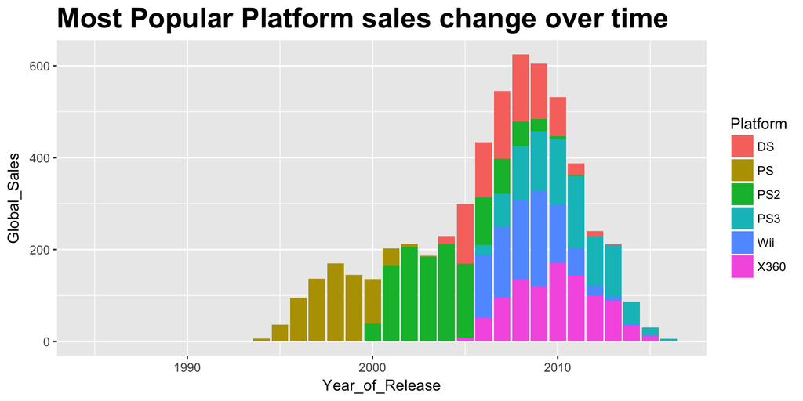

Most popular game platform could still alive in marketing for more than five years. In fact, the most popular game platform are also develop and make from the toppest video game publishers. Thus, enough high quailty video games is necessary for sell well patform.

### Nintendo Evaluation

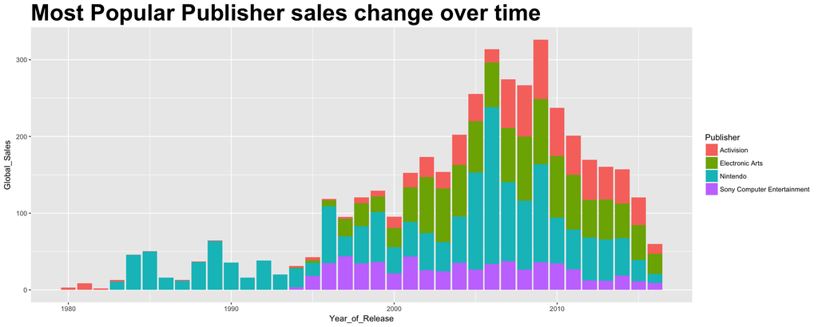

From the above plot, Nintendo is monopolized game market around 1985, but after the powerful companies such as Sony,Activision, and Electronic Arts joined the market. Nintendo’s market share keep falling in the recent year.

# Nintendo in 2017

# Text Mining

## Word Cloud

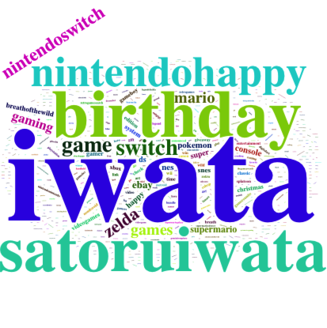

Word Cloud Nintendo

The tweet data was captured in Dec. of 2017. First, I explore how people on Twitter think of Nintendo. By extracting the tweet text messages from the original data frame, I cleaned the text by getting rid of URLs, hashtags, @, unnecessary spaces, retweet headers and meaningless daily words (such as we, can, she, able, etc.). Package “wordcloud2” was used to generate the word cloud here. From the word cloud we could see that postive word such as happy, birthday are mentioned a lot in the tweet text. The former company CEO Satoru Iwata was also appeared pretty frequent. It seems Nintendo brought many postive attitude with customers.

## Sentiment Analysis

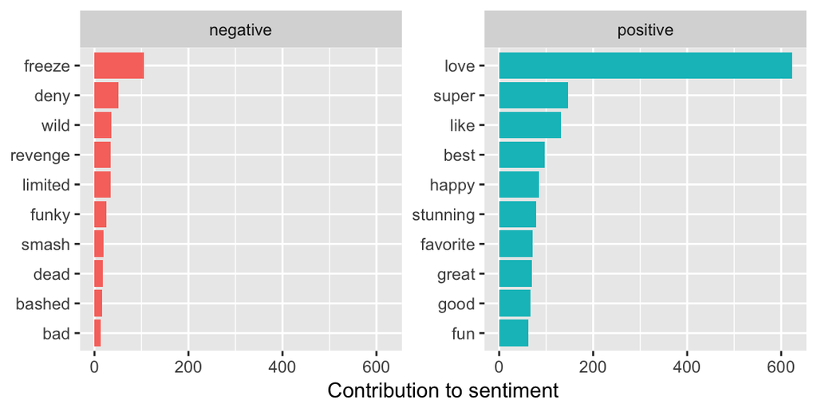

## Frequency Analysis

In this section, I did further frequency analysis of tweet texts in terms of number of characters per tweet, word length per tweet, number of unique words per tweet, number of hashtag per tweet, number of @mentions per tweet. I explored people’s habits about writing tweet texts. It can be seen that as the number of words increases in one tweet, the number of character increases but the size of words per tweet decreases. These two patterns might be similar as the overall writing patterns in Twitter.

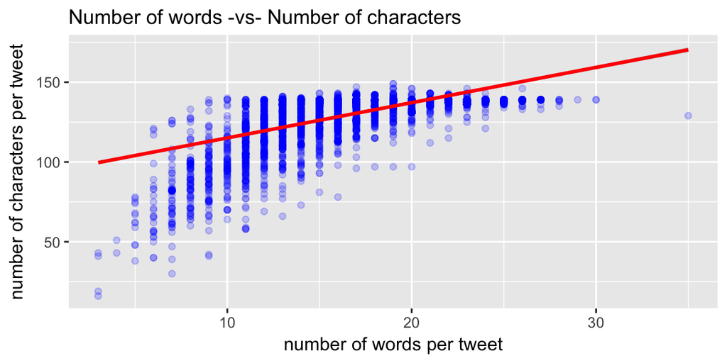

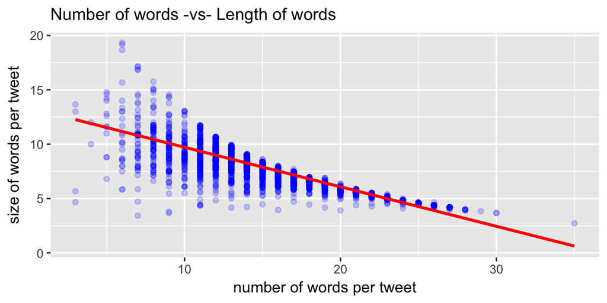

# Discussion

First, I also applied the location information from Twitter API. However, as TA has stated in the lecture, Twitter users can put the location themselves and may not the real one. Hence, it is unreliable. I discarded it.

# Conclusion

In these years, video games occupy more and more time in our life accompany with the development of our life situation and technology.

A big video game producer, like Nintendo, will not only stay a model of business company. But also a game device producer and video game producer.